# CYLISTIC DATA

Dolapo Alonge

2023-03-10

### INTRODUCTION

This is the Cyclistic bikers data analysis, The steps for this analysis process are the Ask, prepare, process, analyze, share and act. Please follow me on the guide.

I am a junior business analyst working in the marketing analyst team at Cyclistic, a bike-share company in Chicago that features more than 5,800 bicycles and 600 docking station.

The director of marketing believes the company’s future success depends on maximizing the number of annual membership. Therefore, my team wants to understand how casual riders and annual members use Cyclistic bikes differently.

### ASK PROCESS

#### BUSINESS TASK

To design marketing strategies aimed at converting casual riders into annual members, how? 1. By understanding how annual members and casual riders use bikes differently, 2. why casual riders would buy a membership, 3. understanding how digital media could affect our marketing tactics.

#### GOAL

Maximize the number of annual membership.

### PREPARE DATA

The data that would be used for analysis is Cyclistic historical trip data from the paszt 12 months (Jan 2022 - Dec 2022) https://divvy-tripdata.s3.amazonaws.com/index.html made available by Motivation International Inc.

I have downloaded the data and opened in Excel spreadsheet, it is very large but structured with each columns having headers, same datatype in each column. Saved in csv format.

The integrity of the data is not verified,

The data has up to date records of trips for analyzing historic data.

The data has null values in some rows and duplicates. I would have to filter and sort the data but I would not using Excel for this.

### PROCESS DATA

I am using R for processing and analyzing, because the dataset is very large and R Studio is an IDE so I can work will be fast and I can do all of the work on here.

First I would load useful packages in R studio for my data.

```r
library(tidyverse) # Cleaning/ Manipulating
library(hms) # Date
library(lubridate)# Time
```

Now that my packages are loaded, I will download the csv files using function read.csv under ‘readr’ package in Tidyverse.

```r
Jan_01 <- read_csv("Dolapo's Docs/STUDIES/Capstone Project/2022 data/202201-divvy-tripdata/New folder/202201-divvy-tripdata.csv")
Feb_02 <- read_csv("Dolapo's Docs/STUDIES/Capstone Project/2022 data/202202-divvy-tripdata/202202-divvy-tripdata.csv")
Mar_03 <- read_csv("Dolapo's Docs/STUDIES/Capstone Project/2022 data/202203-divvy-tripdata/202203-divvy-tripdata.csv")
Apr_04 <- read_csv("Dolapo's Docs/STUDIES/Capstone Project/2022 data/202204-divvy-tripdata/202204-divvy-tripdata.csv")
May_05 <- read_csv("Dolapo's Docs/STUDIES/Capstone Project/2022 data/202205-divvy-tripdata/202205-divvy-tripdata.csv")
Jun_06 <- read_csv("Dolapo's Docs/STUDIES/Capstone Project/2022 data/202206-divvy-tripdata/202206-divvy-tripdata.csv")
Jul_07 <- read_csv("Dolapo's Docs/STUDIES/Capstone Project/2022 data/202207-divvy-tripdata/202207-divvy-tripdata.csv")
Aug_08 <- read_csv("Dolapo's Docs/STUDIES/Capstone Project/2022 data/202208-divvy-tripdata/202208-divvy-tripdata.csv")
Sep_09 <- read_csv("Dolapo's Docs/STUDIES/Capstone Project/2022 data/202209-divvy-tripdata/202209-divvy-publictripdata.csv")
oct_10 <- read_csv("Dolapo's Docs/STUDIES/Capstone Project/2022 data/202210-divvy-tripdata/202210-divvy-tripdata.csv")
Nov_11 <- read_csv("Dolapo's Docs/STUDIES/Capstone Project/2022 data/202211-divvy-tripdata/202211-divvy-tripdata.csv")
Dec_12 <- read_csv("Dolapo's Docs/STUDIES/Capstone Project/2022 data/202212-divvy-tripdata/202212-divvy-tripdata.csv")
```

I already checked the files and saw that the columns in each file are the same, so i can merge them into one dataframe using rbind function.

Merge all the dataframes into one

```r
cylistic_df <- rbind(Jan_01, Feb_02, Mar_03, Apr_04, May_05, Jun_06, Jul_07, Aug_08, Sep_09, oct_10, Nov_11, Dec_12)
```

To create more space, i will use the remove function to delete the individual csv files.

```r
remove(Jan_01, Feb_02, Mar_03, Apr_04, May_05, Jun_06, Jul_07, Aug_08, Sep_09, oct_10, Nov_11, Dec_12)
```

To keep the original dataframe, I will create a new one to work on

create a new dataframe

```r
cylis_new <- cylistic_df
```

manipulating the data by adding these columns for a more comprehensive analysis #add new columns to the cylis_new: date, hour, day of week, days, month.

```r
cylis_new$date <- as.Date(cylis_new$started_at)# default format is yyyy-mm-dd
cylis_new$day_of_week <- wday(cylis_new$started_at)# calculate day of the week
cylis_new$day_of_week <- format(as.Date(cylis_new$date), '%A') # create column for day of the week
cylis_new$days <- format(as.Date(cylis_new$date), '%d') # create column for day
cylis_new$month <- format(as.Date(cylis_new$date), '%m') # create column for month
cylis_new$time <- format(as.Date(cylis_new$date), '%H:%M:%S') #format time as H:M:S
cylis_new$time <- as_hms(cylis_new$started_at) # create column for time
cylis_new$hour <- hour(cylis_new$time)
```

I will add a new column ‘season’ using mutate function on the Month column. #create column for diff seasons: summer, winter, fall, spring

```r
cylis_new <- cylis_new %>% mutate(season =

                                  case_when(month =='01' ~ 'Winter',
                                           month == '02' ~ 'Winter',
                                           month == '03' ~ 'Spring',
                                           month == '04' ~ 'Spring',
                                           month == '05' ~ 'Spring',
                                           month == '06' ~ 'Summer',
                                           month == '07' ~ 'Summer',
                                           month == '08' ~ 'Summer',
                                           month == '09' ~ 'Fall',
                                           month == '10' ~ 'Fall',
                                           month == '11' ~ 'Fall',
                                           month == '12' ~ 'Winter')

)
```

Also, another new column for time of day created from the hour column using mutate function create column for diff time : morning, afternoon, evening, night

```r
cylis_new <- cylis_new %>% mutate(time_of_day =

                                             case_when(hour == "0" ~ "Night",
                                                       hour == "1" ~ "Night",
                                                       hour == "2" ~ "Night",
                                                       hour == "3" ~ "Night",
                                                       hour == "4" ~ "Night",
                                                       hour == "5" ~ "Night",
                                                       hour == "6" ~ "Morning",
                                                       hour == "7" ~ "Morning",
                                                       hour == "8" ~ "Morning",
                                                       hour == "9" ~ "Morning",
                                                       hour == "10" ~ "Morning",
                                                       hour == "11" ~ "Morning",
                                                       hour == "12" ~ "Afternoon",
                                                       hour == "13" ~ "Afternoon",
                                                       hour == "14" ~ "Afternoon",
                                                       hour == "15" ~ "Afternoon",
                                                       hour == "16" ~ "Afternoon",
                                                       hour == "17" ~ "Afternoon",
                                                       hour == "18" ~ "Evening",
                                                       hour == "19" ~ "Evening",
                                                       hour == "20" ~ "Evening",
                                                       hour == "21" ~ "Evening",
                                                       hour == "22" ~ "Evening",
                                                       hour == "23" ~ "Evening")
)
```

Do a calculation to get the ride length of each ride, and change the duration to minutes #Calculate ride_length by subtracting ended_at from started_at

```r
cylis_new$ride_length <- difftime(cylis_new$ended_at, cylis_new$started_at, units = 'mins')
```

clean the data by removing null values using na.omit function, remove duplicates using distinct function, removing errors from my new column (ride length where the duration is a negative figure or 0 and lastly, remove irrelevant columns.

#### clean the data

```r
cylis_new <- na.omit(cylis_new) # remove null values
cylis_new <- distinct(cylis_new) #remove duplicate rows
cylis_new <- cylis_new[!(cylis_new$ride_length <= 0),] # remove where ride_length is negative and zero
cylis_new <- cylis_new %>% select(-c(start_station_id, end_station_id,start_lat,start_lng,end_lat,end_lng))
```

I changed the ride length data type to numeric using as.numeric function and checked the datatype usind is.numeric function.

##### Convertion of ride length to numeric so calculations can be run on the data

```r
cylis_new$ride_length <- as.numeric(as.character(cylis_new$ride_length))
is.numeric(cylis_new$ride_length)
```

```
## [1] TRUE
```

I viewed my data using the View() function.

### ANALYZE

Now my data has been processed and it is ready for analysis, i used groupby(), filter(), count(), summarize(), print() functions for my analysis. I also used the mean() function for aggregating.

I want to see the number of rows I have, which is equivalent to the number of total rides for the year 2022.

###TOTAL RIDES

```r
nrow(cylis_new)
```

```
## [1] 4369052
```

I did calculations for 1. total rides, 2. count of member type, 3. count of rideable bikes, 4. count of rides per hour, 5. by time of day, 6. by day of week, 7. by day,- 8. by month and 9. by season.

Grouping by casual riders and annual members to see differences in the way the used the bikes

I also did an average aggregate on each of the items above (The codes are in my script).

### SUMMARY OF ANALYSIS

It was interesting working with this data and analyzing it, i will state the insights i got from this analysis: The total number of rides in the year 2022 is 4,369,052, Annual Members - 2,611,005 and casual riders - 1,758,047

Three bikes were used by the riders: Classic, Electrical and Docked bikes. The most used bike by both riders is the classic bike. Only the Casual riders used the Docked Bikes.

The busiest time of the day for the riders is in the afternoon, with 17:00hrs being the most rushed hour for both riders.

For the days in the week, the riders rode differently. The Annual members rode more during the week with Thursday being their busiest day- and Sunday being the least day. The casual riders used the bikes more on weekends with Saturday being the busiest day and Tuesday, with the smallest number of rides.

The busiest month of the year for Annual Member is August - 335,201 with July - 330,980 closely behind. For the casual Riders, July was the busiest month in year 2022 with 311,649 number of rides. The least rides in a month for both riders was the month of January, with February being the 2nd least. Summer being the busiest season and Winter the least.

Streeter Dr & Grand Ave is the most popular start station used by causal riders by 55,054 rides and Kingsbury St & Kinzie St is the most popular start station among the Annual member riders by 23,523 rides.

### SHARE

Next step is to visualize my data, i will be using ggplot2 package on R for my viz the function is ggplot()

#### Total Count of Member Type

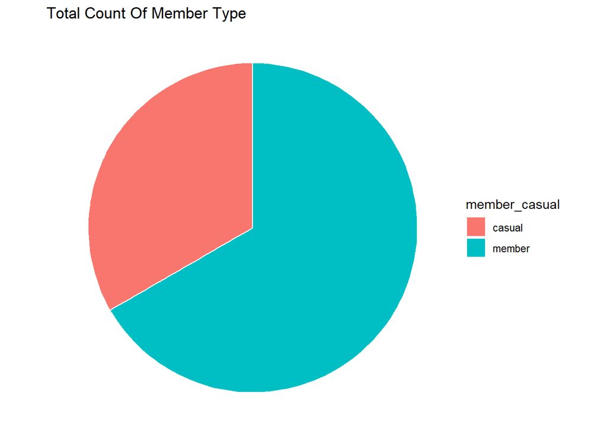

```r
cylis_new %>%
  group_by(member_casual)%>%
  summarize(count_mem = n())%>%
  ggplot(aes( x = '',y = member_casual, fill = member_casual)) +
  geom_bar( stat = 'identity', width = 1, color = 'white' )+
  coord_polar( 'y', start = 0)+
  theme_void()+ # remove background, grid, numeric labels
  labs(title = 'Total Count Of Member Type', x = 'Member Type', y = 'Count of Trips')
```

```r
cylis_new %>%
  group_by(member_casual) %>%
  count(member_casual)
```

```
## # A tibble: 2 × 2
## # Groups:   member_casual [2]
##   member_casual       n
##   <chr>           <int>
## 1 casual        1758047
## 2 member        2611005
```

#### Total Count Of Bikes

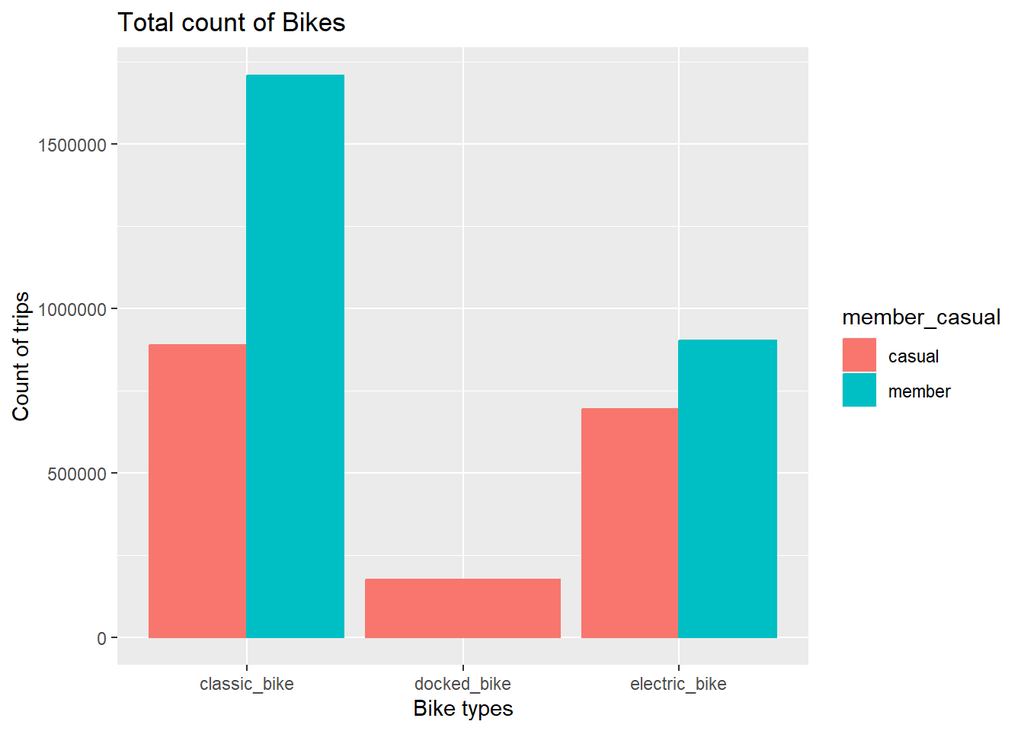

```r
cylis_new %>%
  group_by(member_casual,rideable_type)%>%
  summarise(count_bike = n()) %>%
  ggplot(aes(x = rideable_type, y = count_bike, fill = member_casual, color = member_casual)) +
  geom_bar( stat ='identity', position = 'dodge')+
  labs(title = 'Total count of Bikes', x = 'Bike types', y = 'Count of trips')
```

```r
cylis_new %>%
  group_by(member_casual, rideable_type) %>%
  count(rideable_type)
```

```
## # A tibble: 5 × 3
## # Groups:   member_casual, rideable_type [5]
##   member_casual rideable_type       n
##   <chr>         <chr>           <int>
## 1 casual        classic_bike   888728
## 2 casual        docked_bike    174852
## 3 casual        electric_bike  694467
## 4 member        classic_bike  1708573
## 5 member        electric_bike  902432
```

```r
#total ride
cylis_new %>%
  group_by(rideable_type)%>%
  count(rideable_type)
```

```
## # A tibble: 3 × 2
## # Groups:   rideable_type [3]
##   rideable_type       n
##   <chr>           <int>
## 1 classic_bike  2597301
## 2 docked_bike    174852
## 3 electric_bike 1596899
```

#### Total Count of Ride Per Hour

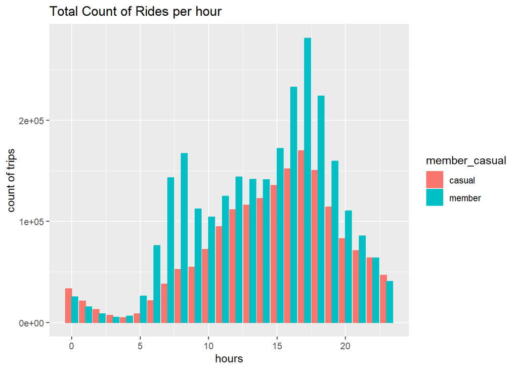

```r
cylis_new %>%
  group_by(member_casual, hour)%>%
  summarise(count_trip = n()) %>%
  ggplot(aes(x = hour, y = count_trip, fill = member_casual, color = member_casual))+
  geom_bar(stat = 'identity', position = 'dodge')+
  labs(title = 'Total Count of Rides per hour', x = 'hours', y = 'count of trips')
```

#### Num of rides by Time of day

#### total ride by membertype

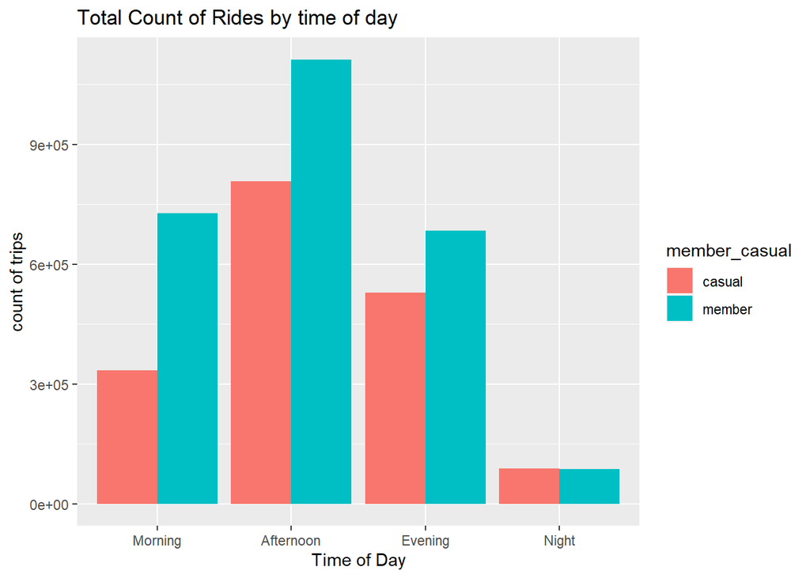

```r
cylis_new$time_of_day <- ordered(cylis_new$time_of_day, levels = c("Morning", "Afternoon", "Evening", "Night"))

cylis_new %>%
  group_by(member_casual, time_of_day) %>%
  summarize(count_trip = n())%>%
  ggplot(aes(x =time_of_day, y = count_trip, fill = member_casual, cololr = member_casual))+
  geom_bar(stat = 'identity', position = 'dodge')+
  labs(title = 'Total Count of Rides by time of day', x = 'Time of Day', y = 'count of trips')
```

#### Num Of Rides by Day of the week

#### Arrange day of week

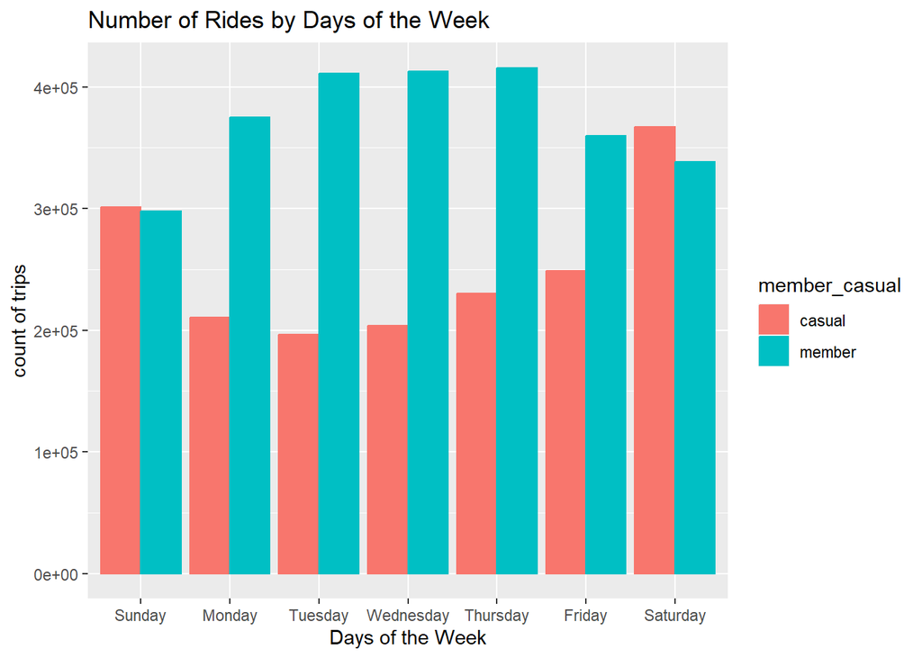

```r
cylis_new$day_of_week <- ordered(cylis_new$day_of_week, levels = c("Sunday", "Monday", "Tuesday", "Wednesday", "Thursday", "Friday", "Saturday"))

cylis_new %>%
  group_by(member_casual, day_of_week)%>%
  summarise(count_trip = n()) %>%
  ggplot(aes(x = day_of_week, y = count_trip, fill = member_casual, color = member_casual))+
  geom_bar(stat = 'identity', position = 'dodge')+
  labs(title = 'Number of Rides by Days of the Week', x = 'Days of the Week', y = 'count of trips')
```

```r
cylis_new %>%
  group_by(member_casual) %>%
  count(day_of_week)%>%
  arrange(-n)
```

```
## # A tibble: 14 × 3
## # Groups:   member_casual [2]
##    member_casual day_of_week      n
##    <chr>         <ord>        <int>
##  1 member        Thursday    415862
##  2 member        Wednesday   412775
##  3 member        Tuesday     411226
##  4 member        Monday      375151
##  5 casual        Saturday    367310
##  6 member        Friday      360029
##  7 member        Saturday    338255
##  8 casual        Sunday      301278
##  9 member        Sunday      297707
## 10 casual        Friday      248785
## 11 casual        Thursday    229993
## 12 casual        Monday      210746
## 13 casual        Wednesday   203568
## 14 casual        Tuesday     196367
```

```r
#total ride
cylis_new %>%
  count(day_of_week)
```

```
## # A tibble: 7 × 2
##   day_of_week      n
##   <ord>        <int>
## 1 Sunday      598985
## 2 Monday      585897
## 3 Tuesday     607593
## 4 Wednesday   616343
## 5 Thursday    645855
## 6 Friday      608814
## 7 Saturday    705565
```

#### Number of rides by Month

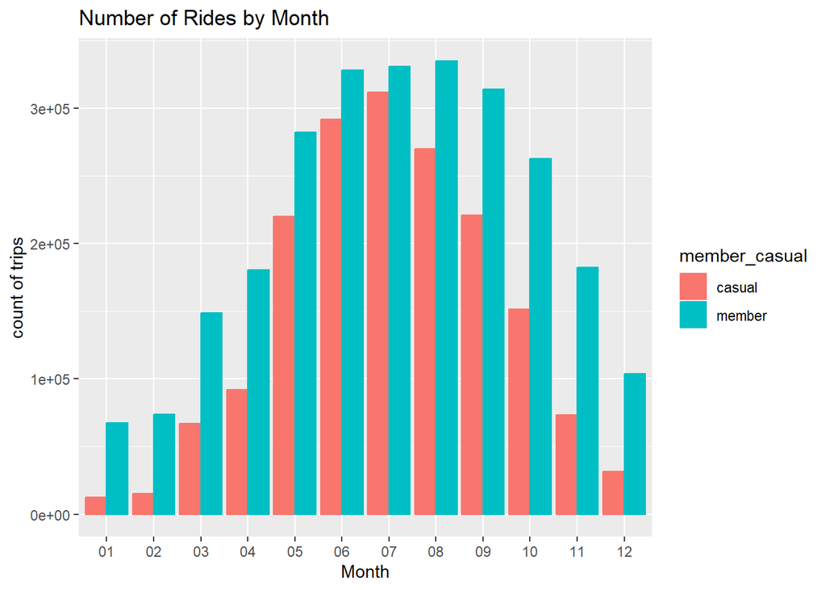

```r
cylis_new %>%
  group_by(member_casual, month)%>%
  summarise(count_trip = n()) %>%
  ggplot(aes(x = month, y = count_trip, fill = member_casual, color = member_casual))+
  geom_bar(stat = 'identity', position = 'dodge')+
  labs(title = 'Number of Rides by Month', x = 'Month', y = 'count of trips')
```

```r
#Casual
cylis_new %>%
  group_by(member_casual) %>%
  filter(member_casual == 'casual')%>%
  count(month)%>%
  arrange(-n)%>%
  print(n = 12)
```

```
## # A tibble: 12 × 3
## # Groups:   member_casual [1]
##    member_casual month      n
##    <chr>         <chr>  <int>
##  1 casual        07    311649
##  2 casual        06    292053
##  3 casual        08    270074
##  4 casual        09    220905
##  5 casual        05    220232
##  6 casual        10    151312
##  7 casual        04     91889
##  8 casual        11     73533
##  9 casual        03     67150
## 10 casual        12     31502
## 11 casual        02     15143
## 12 casual        01     12605
```

```r
#Member
cylis_new %>%
  group_by(member_casual) %>%
  filter(member_casual == 'member')%>%
  count(month)%>%
  arrange(-n)%>%
  print(n = 12)
```

```
## # A tibble: 12 × 3
## # Groups:   member_casual [1]
##    member_casual month      n
##    <chr>         <chr>  <int>
##  1 member        08    335201
##  2 member        07    330980
##  3 member        06    328258
##  4 member        09    314214
##  5 member        05    282284
##  6 member        10    262926
##  7 member        11    182219
##  8 member        04    180657
##  9 member        03    148821
## 10 member        12    103891
## 11 member        02     74031
## 12 member        01     67523
```

#### Number of Rides By Season

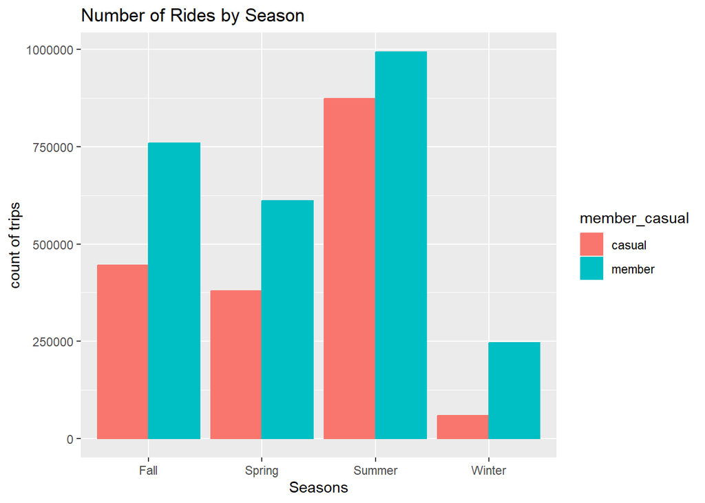

```r
cylis_new %>%
  group_by(member_casual, season)%>%
  summarise(count_trip = n()) %>%
  ggplot(aes(x = season, y = count_trip, fill = member_casual, color = member_casual))+
  geom_bar(stat = 'identity', position = 'dodge')+
  labs(title = 'Number of Rides by Season', x = 'Seasons', y = 'count of trips')
```

#### AVERAGE RIDE LENGTH—-

##### avg ride_length

```r
cyclistic_rideAvg <- mean(cylis_new$ride_length)
print(cyclistic_rideAvg)
```

```
## [1] 17.09677
```

```r
#---By member type---
#Avg ride_length
cylis_new %>%
  group_by(member_casual)%>%
  summarize(ride_avg= mean(ride_length))
```

```
## # A tibble: 2 × 2
##   member_casual ride_avg
##   <chr>            <dbl>
## 1 casual            24.0
## 2 member            12.5
```

#### Most Popular start stations by Casual Bikers

```r
cylis_new %>%
  group_by(member_casual, start_station_name)%>%
  summarise(num_of_ride = n())%>%
  filter(start_station_name != "", "casual"== member_casual)%>%
  arrange(-num_of_ride)%>%
  print( n = 5)
```

```
## # A tibble: 1,454 × 3
## # Groups:   member_casual [1]
##   member_casual start_station_name                 num_of_ride
##   <chr>         <chr>                                    <int>
## 1 casual        Streeter Dr & Grand Ave                  55054
## 2 casual        DuSable Lake Shore Dr & Monroe St        30261
## 3 casual        Millennium Park                          23948
## 4 casual        Michigan Ave & Oak St                    23760
## 5 casual        DuSable Lake Shore Dr & North Blvd       22156
## # … with 1,449 more rows
```

```r
cylis_new %>%
  group_by(member_casual, start_station_name)%>%
  summarise(num_of_ride = n())%>%
  filter(start_station_name != "", "member"== member_casual)%>%
  arrange(-num_of_ride)%>%
  print( n = 5)
```

```
## # A tibble: 1,384 × 3
## # Groups:   member_casual [1]
##   member_casual start_station_name           num_of_ride
##   <chr>         <chr>                              <int>
## 1 member        Kingsbury St & Kinzie St           23523
## 2 member        Clark St & Elm St                  20578
## 3 member        Wells St & Concord Ln              19674
## 4 member        Clinton St & Washington Blvd       18828
## 5 member        Loomis St & Lexington St           18252
## # … with 1,379 more rows
```

### ACT

My final conclusion is that the riders rode a bit differently in bike type and settings. Getting the casual riders to become members is very possible because they are frequent riders and they could save their resources by becoming members.

Additional data i could use to expand on my findings is more data on the personal information of riders (Sex, age, occupation etc).